**Jenish Vinodbhai Dhaduk**

**Student ID- 989354198**

Topic Name - Employment analysis for the city.

# 1.Introduction.

The San Francisco Chronicle newspaper requires some meaningful information about the cost of living in the city to publish as a main page article. For that a dataset from the San Francisco Controller's Office is given for analysis. The San Francisco Controller's Office maintains a database of the salary and benefits paid to City employees.

The dataset contains various information about each city employee in 22 different columns like, 1.In which department they are woking. 2.How much compensation each employee is getting ? 3.what is the total salary of each employee. 4.The overtime history of each employee.

Mostly the articles that are supposed to be printed on the first page of newspaper has to be something that makes people want to buy newspaper. Some interesting facts about their own city might attracts people attention. Therefore, newspaper needs some interesting facts and figures about the various jobs in the city. A table representing the top job titles in different working aspects can be helpful to The San Francisco Chronicle newspaper.

```r
main<-read.csv(file.choose())
```

Reads the "employee-compensation" dataset.

# 2. Data Exploration.

```r
library('tidyr')
library('dplyr')
library('ggplot2')
sum<-summary(main)
sum
```

```
    Year.Type           Year      Organization.Group.Code
 Calendar:499765   Min.   :2013   Min.   :1.000
 Fiscal  :335542   1st Qu.:2015   1st Qu.:2.000
                   Median :2017   Median :4.000
                   Mean   :2017   Mean   :3.718
                   3rd Qu.:2018   3rd Qu.:6.000
                   Max.   :2028   Max.   :7.000

                                Organization.Group           Department.Code
 Community Health                        :148821   DPH               :148821
 Culture & Recreation                    : 61716   MTA               : 99167
 General Administration & Finance        : 62266   POL               : 54755
 General City Responsibilities           :154582   REC               : 38327
 Human Welfare & Neighborhood Development: 61880   DSS               : 35392
 Public Protection                       :131841   __NOT_APPLICABLE__: 31837
 Public Works, Transportation & Commerce :214201   (Other)           :427008
                         Department       Union.Code
                              :400498   Min.   :  1.0
 DPH Public Health            : 94616   1st Qu.:250.0
 MTA Municipal Transprtn Agncy: 63852   Median :535.0
 HSA Human Services Agency    : 35392   Mean   :490.6
 POL Police                   : 34548   3rd Qu.:790.0
 REC Recreation & Park Commsn : 24136   Max.   :990.0
 (Other)                      :182265   NA's   :561
                                             Union        Job.Family.Code
 SEIU, Local 1021, Misc                         :151867   2300   : 82526
 SEIU - Miscellaneous, Local 1021               :122940   9100   : 69190
 Prof & Tech Eng, Local 21                      : 60497   Q000   : 53443
 Prof & Tech Engineers - Miscellaneous, Local 21: 55771   7300   : 48907
 SEIU - Staff and Per Diem Nurses, Local 1021   : 32880   2900   : 43806
 Police Officers' Association                   : 28171   9900   : 36784
 (Other)                                        :383181   (Other):500651
               Job.Family        Job.Code                          Job
 Nursing            : 82526   9163   : 52300   Transit Operator      : 52300
 Street Transit     : 69190   P103   : 28242   Special Nurse         : 28242
 Police Services    : 53443   2320   : 26104   Registered Nurse      : 26104
 Journeyman Trade   : 48907   H002   : 17190   Firefighter           : 17190
 Human Services     : 43806   2708   : 16218   Custodian             : 16218
 Public Service Aide: 36784   9910   : 16108   Public Service Trainee: 16108
 (Other)            :500651   (Other):679145   (Other)               :679145
```

[output cut: 8 more lines]

```
  Total.Salary      Retirement     Health.and.Dental Other.Benefits
 Min.   :-68772   Min.   :-30469   Min.   :-2940     Min.   :-10636.5
 1st Qu.:  6500   1st Qu.:     0   1st Qu.: 2162     1st Qu.:   425.6
 Median : 56975   Median : 10550   Median :11492     Median :  3131.3
 Mean   : 61118   Mean   : 10570   Mean   : 9461     Mean   :  4065.9
 3rd Qu.: 95825   3rd Qu.: 17278   3rd Qu.:13371     3rd Qu.:  6436.2
 Max.   :652548   Max.   :120791   Max.   :36370     Max.   : 39451.3

 Total.Benefits   Total.Compensation
 Min.   :-21295   Min.   :-74083
 1st Qu.:  1533   1st Qu.:  8755
 Median : 25503   Median : 84437
 Mean   : 24134   Mean   : 85252
 3rd Qu.: 40061   3rd Qu.:136202
 Max.   :160646   Max.   :813194
```

2.1 Summary function provides the Brief information about the selected Dataset.

```r
head(main,n=10)
```

| Year.Type | Year | Organization.Group.Code | Organization.Group | Department.Code | Department | Union.Code | Union | Job.Family.Code | Job.Family | ... | Employee.Identifier | Salaries | Overtime | Other.Salaries | Total.Salary | Retirement | Health.and.Dental | Other.Benefits | Total.Benefits | Total.Compensation |
| --- | --- | --- | --- | --- | --- | --- | --- | --- | --- | --- | --- | --- | --- | --- | --- | --- | --- | --- | --- | --- |
| Calendar | 2028 | 7 | General City Responsibilities | 229259 |  | 792 | Utd Pub EmpL790 SEIU-Crt Clrks | 0000 | Untitled | ... | 8540990 | 674.28 | 0.00 | 5.76 | 680.04 | 130.91 | 0.00 | 53.86 | 184.77 | 864.81 |
| Calendar | 2028 | 1 | Public Protection | CRT |  | 792 | Utd Pub EmpL790 SEIU-Crt Clrks | 0000 | Untitled | ... | 8540990 | 674.28 | 0.00 | 5.76 | 680.04 | 130.91 | 0.00 | 53.86 | 184.77 | 864.81 |
| Fiscal | 2028 | 1 | Public Protection | CRT |  | 792 | Utd Pub EmpL790 SEIU-Crt Clrks | 0000 | Untitled | ... | 8540990 | 674.28 | 0.00 | 5.76 | 680.04 | 130.91 | 0.00 | 53.86 | 184.77 | 864.81 |
| Calendar | 2019 | 7 | General City Responsibilities | 232108 |  | 911 | POA | Q000 | Police Services | ... | 8577148 | 124709.01 | 100499.62 | 5501.78 | 230710.41 | 23271.86 | 14293.60 | 3934.00 | 55975.56 | 286685.97 |
| Calendar | 2019 | 1 | Public Protection | DAT |  | 311 | Municipal Attorneys Assoc | 8100 | Legal & Court | ... | 8603109 | 155489.01 | 0.00 | 1500.00 | 156989.01 | 29239.75 | 14308.46 | 11100.60 | 69326.83 | 226315.84 |
| Calendar | 2019 | 7 | General City Responsibilities | 102644 |  | 130 | Auto Machinist, Local 1414 | 7300 | Journeyman Trade | ... | 8547213 | 69490.84 | 34969.05 | 13344.53 | 117804.42 | 16424.93 | 14308.44 | 9651.75 | 48573.42 | 166377.84 |
| Calendar | 2019 | 7 | General City Responsibilities | DEM |  | 790 | SEIU, Local 1021, Misc | 8200 | Protection & Apprehension | ... | 8544058 | 57062.72 | 6033.18 | 1192.00 | 64287.90 | 11851.05 | 14308.40 | 5473.16 | 33664.43 | 97952.33 |
| Calendar | 2019 | 7 | General City Responsibilities | 102644 |  | 253 | TWU, Local 250-A, TransitOpr | 9100 | Street Transit | ... | 8504938 | 74231.85 | 22440.63 | 3619.49 | 100291.97 | 14778.60 | 14634.18 | 7600.99 | 52233.11 | 152525.08 |
| Calendar | 2019 | 4 | Community Health | DPH |  | 858 | Teamsters, Local 856, Spv RN | 2300 | Nursing | ... | 8559329 | 22348.10 | 5032.61 | 1755.83 | 29136.54 | 4488.15 | 0.00 | 1739.06 | 6227.21 | 35363.75 |
| Calendar | 2019 | 1 | Public Protection | POL |  | 911 | POA | Q000 | Police Services | ... | 8506973 | 0.00 | 2911.35 | 0.00 | 2911.35 | 0.00 | 0.00 | 0.00 | 0.00 | 2911.35 |

2.2 The above table shows the first 10 rows of the main dataset.

```r
mean(main$Salaries)
maxsalary<-max(main$Salaries)
maxsalary
```

54096.8067953818

645739.46

2.3 Above function is used to calculate the mean value of salaries for all employees and the maximum value in the column that is the highest salary paid to any employee.

```r
ncol(main)
nrow(main)
```

22

835307

2.4 It gives the information about the total column and total rows in the given dataset.

# 3. Data Subset

Subsets of Data: Produce 5 different subsets relevant to the newspaper, containing distinct rows and columns. Your results should be relevant help the newspaper show the facts of employment.

```r
subset1<-subset(main,
                select=c(Department.Code,Organization.Group,Organization.Group.Code) )
tail(subset1,n=10)
```

|  | Department.Code | Organization.Group | Organization.Group.Code |
| --- | --- | --- | --- |
| 835298 | POL | Public Protection | 1 |
| 835299 | TTX | General Administration & Finance | 6 |
| 835300 | PUC | Public Works, Transportation & Commerce | 2 |
| 835301 | CON | General Administration & Finance | 6 |
| 835302 | AIR | Public Works, Transportation & Commerce | 2 |
| 835303 | ASR | General Administration & Finance | 6 |
| 835304 | REC | Culture & Recreation | 5 |
| 835305 | MTA | Public Works, Transportation & Commerce | 2 |
| 835306 | POL | Public Protection | 1 |
| 835307 | DBI | Public Works, Transportation & Commerce | 2 |

Subset1 gives information about the Organization and its department code and organization group code.

```r
subset2<-subset(main, main$Total.Compensation >= 10000, select=c(Year.Type,Year,Job,Total.Compensation ) )
head(subset2)
```

|  | Year.Type | Year | Job | Total.Compensation |
| --- | --- | --- | --- | --- |
| 4 | Calendar | 2019 | Police Officer 3 | 286685.97 |
| 5 | Calendar | 2019 | Attorney (Civil/Criminal) | 226315.84 |
| 6 | Calendar | 2019 | Automotive Machinist | 166377.84 |
| 7 | Calendar | 2019 | Public SafetyComm Disp | 97952.33 |
| 8 | Calendar | 2019 | Transit Operator | 152525.08 |
| 9 | Calendar | 2019 | Nursing Supervisor | 35363.75 |

Subset2 gives infromation about the employee's job title and its total compensation.

```r
subset3<-subset(main, main$Total.Salary <= 50000,select=c(Year.Type,Year,Total.Benefits,Total.Salary) )
tail(subset3,n=10)
```

|  | Year.Type | Year | Total.Benefits | Total.Salary |
| --- | --- | --- | --- | --- |
| 835282 | Fiscal | 2013 | 5471.67 | 12505.50 |
| 835284 | Fiscal | 2013 | 8184.25 | 19511.40 |
| 835286 | Fiscal | 2013 | 25746.54 | 44749.09 |
| 835290 | Fiscal | 2013 | 9139.89 | 26488.00 |
| 835293 | Fiscal | 2013 | 13020.15 | 15059.42 |
| 835294 | Fiscal | 2013 | 20163.85 | 43579.75 |
| 835295 | Fiscal | 2013 | 2894.11 | 5811.70 |
| 835297 | Fiscal | 2013 | 20566.35 | 42876.79 |
| 835302 | Fiscal | 2013 | 5448.12 | 12592.35 |
| 835303 | Fiscal | 2013 | 17266.05 | 36688.48 |

Subset3 helps to understand the employee's total benefits and total salary.

```r
subset4<-subset(main, main$Retirement >= 50000, select=c(Year.Type,Year,Retirement) )
head(subset4)
```

|  | Year.Type | Year | Retirement |
| --- | --- | --- | --- |
| 784 | Calendar | 2019 | 50024.82 |
| 2060 | Calendar | 2019 | 52711.38 |
| 2555 | Calendar | 2019 | 59723.48 |
| 2633 | Calendar | 2019 | 55332.78 |
| 2824 | Calendar | 2019 | 56774.00 |
| 3150 | Calendar | 2019 | 52337.39 |

Subset4 allows to calculate the total amount spent on retirement for each employee every year whose annual retirement is aboove 50000.

```r
subset5<-subset(main, main$Other.Salaries >= 15000 & main$Other.Benefits >= 15000,
                select=c(Year.Type,Year,Other.Salaries,Other.Benefits) )
head(subset5)
```

|  | Year.Type | Year | Other.Salaries | Other.Benefits |
| --- | --- | --- | --- | --- |
| 1858 | Calendar | 2019 | 15574.04 | 30897.31 |
| 2580 | Calendar | 2019 | 23474.71 | 20351.26 |
| 7362 | Calendar | 2019 | 160358.03 | 28051.81 |
| 10553 | Calendar | 2019 | 160358.03 | 28051.81 |
| 10901 | Calendar | 2019 | 55899.34 | 19889.74 |
| 14841 | Calendar | 2019 | 25067.51 | 20324.40 |

Subset5 shows the other salaries for an employees and also tells about other benefits for an employee.

# 4.Single vector

```r
Jobs_by_department<-main %>%
  select(Department) %>%
  group_by(Department) %>%
  count(Department) %>%
  arrange(desc(n))
head(Jobs_by_department,n=6)
```

| Department | n |
| --- | --- |
|  | 400498 |
| DPH Public Health | 94616 |
| MTA Municipal Transprtn Agncy | 63852 |
| HSA Human Services Agency | 35392 |
| POL Police | 34548 |
| REC Recreation & Park Commsn | 24136 |

```r
Jobs_title<-main %>%
  select(Job) %>%
  group_by(Job) %>%
  count(Job) %>%
  arrange(desc(n))
top5_higest_number_of_jobs<-head(Jobs_title,n=5)
#top5_higest_number_of_jobs
top_jobtitle_vector <- top5_higest_number_of_jobs$Job
print(top_jobtitle_vector,max.levels = 0)
#c('Transit Operator','Special Nurse','Registered Nurse','Firefighter','Custodian')
```

```
[1] Transit Operator Special Nurse    Registered Nurse Firefighter
[5] Custodian
```

A vector is used to store top 5 job titles with highest number of employees. This can be the important finding to publish in newspaper.

# 5. Five Different Lists

5 different Lists: Use R to store a column of your choice in 5 different lists. Find a way to make it business oriented by explaining your list in a relevant format.

Lets use lists to store some of the jobs title from few departments seperately. That will help to understand what job title comes under which specific department.

```r
depa="MTA Municipal Transprtn Agncy"
group1<-main %>% filter(Department == depa) %>%
  select(Job)
list1<-tail(group1,n=3)
list1
```

|  | Job |
| --- | --- |
| 63850 | Electrical Transit System Mech |
| 63851 | Transit Operator |
| 63852 | Welder |

List1 is used to store the some of the job titles from department "MTA Municipal Transprtn Agncy".

```r
depa="DPH Public Health"
group2<-main %>% filter(Department == depa) %>%
  select(Job)
list2<-head(group2,n=3)
list2
```

| Job |
| --- |
| Senior Health Program Planner |
| Registered Nurse |
| Eligibility Worker |

List2 is used to store the some of the job titles from department "DPH Public Health".

```r
depa="HSA Human Services Agency"
group3<-main %>% filter(Department == depa) %>%
  select(Job)
list3<-head(group3,n=3)
list3
```

| Job |
| --- |
| Human Services Technician |
| Protective Services Worker |
| Senior Eligibility Worker |

List3 is used to store the some of the job titles from department "HSA Human Services Agency".

```r
depa="POL Police"
group4<-main %>% filter(Department == depa) %>%
  select(Job)
list4<-tail(group4,n=3)
list4
```

|  | Job |
| --- | --- |
| 34546 | Lieutenant 3 |
| 34547 | Police Officer 3 |
| 34548 | Inspector 3 |

List4 is used to store the some of the job titles from department "POL Police".

```r
depa="REC Recreation & Park Commsn"
group5<-main %>% filter(Department == depa) %>%
  select(Job)
list5<-head(group5,n=3)
list5
```

| Job |
| --- |
| Public Service Trainee |
| Swimming Instructor |
| Communications Dispatcher 1 |

List5 is used to store the some of the job titles from department "REC Recreation & Park Commsn".

# 6.Conditionals

6.1 Seperate the employes on the basis of their salary.

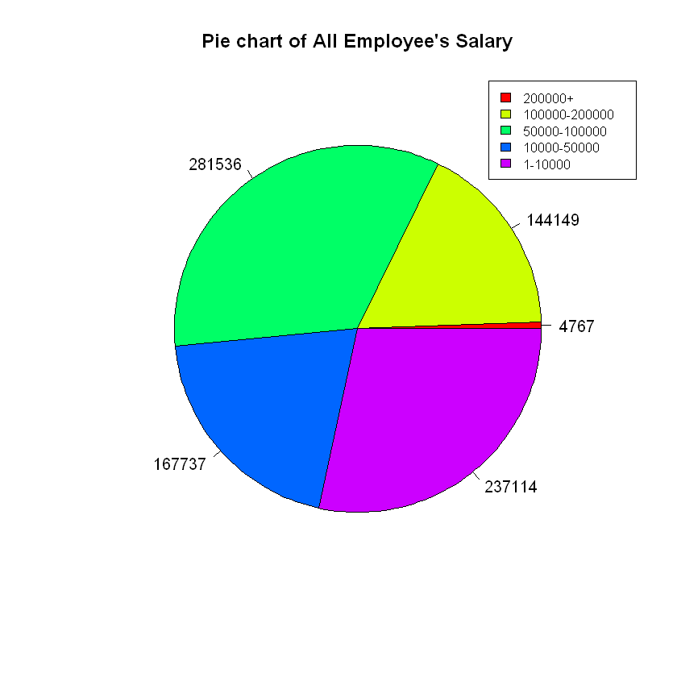

```r
library('ggplot2')
sal_distri<-subset(main, select=c(Salaries) )
sal_vector <- sal_distri$Salaries
above100k = 0
in50k100k = 0
in10k50k = 0
below10k = 0
above200k = 0

for(i in sal_vector )
   {
    if(i < 10000)
    {
        below10k = below10k + 1
    }
    if(i < 50000 && i > 10000)
        {
        in10k50k = in10k50k + 1
    }
    if(i < 100000 && i > 50000)
        {
        in50k100k = in50k100k + 1
    }
     if(i < 200000 && i > 100000)
        {
        above100k = above100k + 1
    }
       if(i > 200000 )
        {
        above200k = above200k + 1
    }
   }

x <- c(above200k,above100k,in50k100k,in10k50k,below10k)

label <- c("200000+","100000-200000","50000-100000","10000-50000","1-10000")

pie(x, x, main = "Pie chart of All Employee's Salary", col = rainbow(length(x)))

legend("topright", label, cex = .8,  fill = rainbow(length(x)))


#loopcount- 1
#conditionalcount- 1
```

Above pie chart signifies the employee's salary bracket. i.e how many employee comes under particular salary bracket.

6.2 Seperate the employes on the basis of the total compensation.

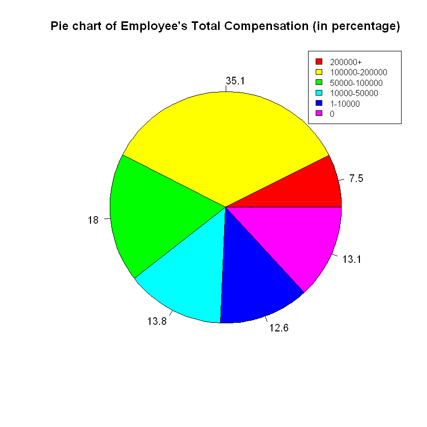

```r
library('ggplot2')
comp_distri<-subset(main, select=c(Total.Compensation ) )
comp_vector <- comp_distri$Total.Compensation
above100k = 0
in50k100k = 0
in10k50k = 0
below10k = 0
zerocomp = 0
above200k = 0

for(i in comp_vector )
   {
    if(i == 0)
    {
    zerocomp = zerocomp+1
    }
    if(i < 10000 && i > 0)
    {
        below10k = below10k + 1
    }
    if(i < 50000 && i > 10000)
        {
        in10k50k = in10k50k + 1
    }
    if(i < 100000 && i > 50000)
        {
        in50k100k = in50k100k + 1
    }
     if(i < 200000 && i > 100000)
        {
        above100k = above100k + 1
    }
       if(i > 200000 )
        {
        above200k = above200k + 1
    }
   }

x <- c(above200k,above100k,in50k100k,in10k50k,below10k,zerocomp)
lables <- c("200000+","100000-200000","50000-100000","10000-50000","1-10000","0")
piepercent<- round(100*x/sum(x), 1)

pie(x, labels = piepercent, main = "Pie chart of Employee's Total Compensation (in percentage)",col = rainbow(length(x)))
legend("topright", lables, cex = .8,
   fill = rainbow(length(x)))

#loopcount- 2
#conditionalcount- 2
```

The above pie chart represent the percentage of employees and their total compensation barcaket.